# Example Code making Hypervolumes with raw mixing model results

W. Ryan James

Here is an example for how to use mixing model output data to generate the trophic niche of 2 consumers from 2 systems using raw mixing model estimates (i.e. estimates from individual samples) calculated using `MixSIAR`.

This script gives examples of how to:

1. Load `MixSIAR` output into R with a custom function
2. Z-score axes used to generate hypervolumes
3. Generate trophic niche hypervolumes using raw mixing model estimates
4. Generate plots of hypervolumes
5. Calculate niche size (volume)
- calculate bootstrapped niche size with custom function to estimate confidence intervals of niche size
6. Calculate overlap between two hypervolumes
- calculate bootstrapped overlap metrics to estimate confidence intervals of overlap

### Load requried packages

```r
library(tidyverse)
library(hypervolume)
```

### Load mixing model data

This is a custom function that was written to import the output of the mixing models

**note** for this to work, all columns must be on the same row like this:

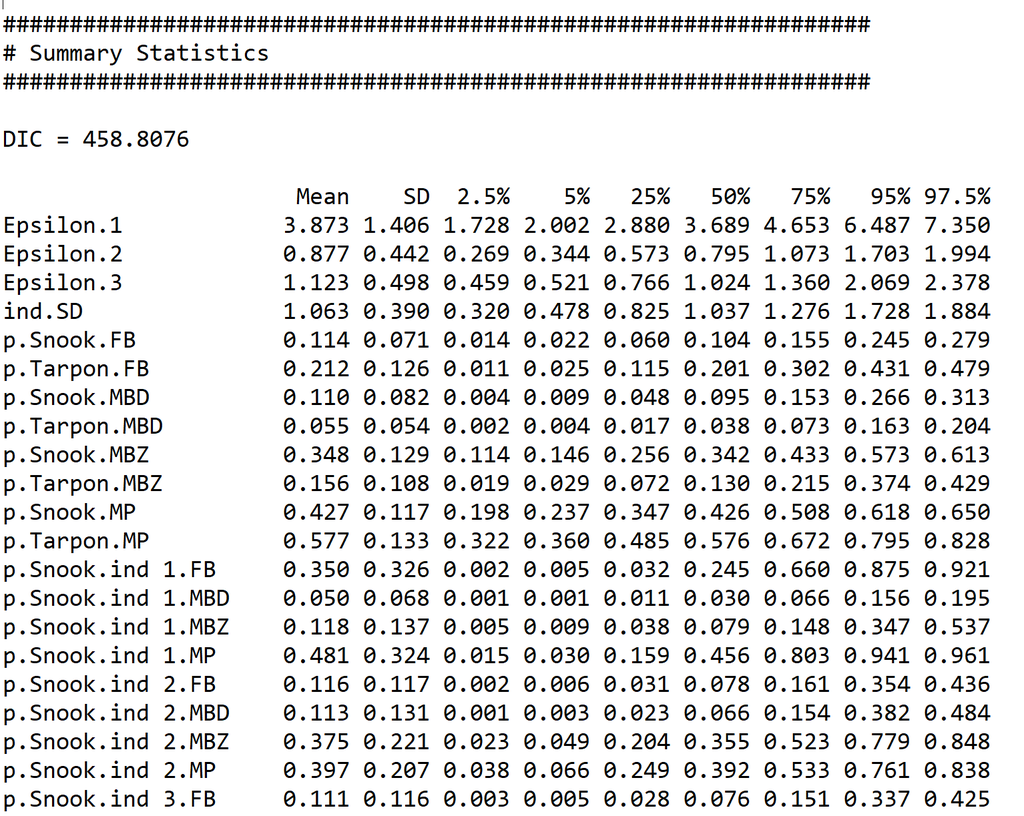

and not wrapped like this:

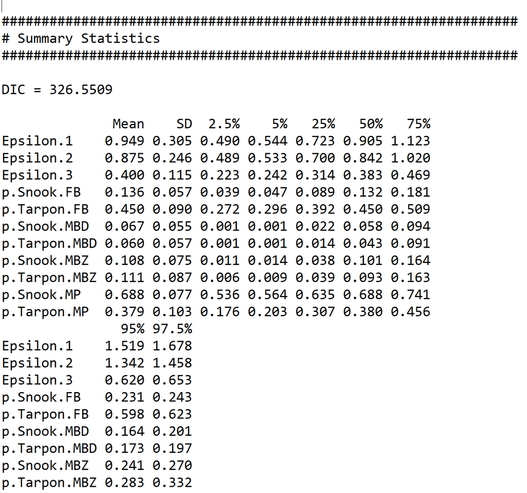

Use the `mixTable` function to load data

`file =` name of name of .txt of summary stats from `MixSIAR`

`site =` ‘site’ or ‘location’ of the data set

`ind = F` if `TRUE` will output with columns as source values, default is `FALSE` and will output data with columns as mean, sd, and posterior distribution quantiles: lowend = 2.5%, highend = 97.5%, mid = 50%, low = 25%, up = 75%, ymax = 75% quantile + 1.5 * IQR, ymin = 25% quantile - 1.5 * IQR

`nest = F` if nested mixing model, `TRUE` will return the sources of nested

```r
mixTable = function(file,site,ind = F,nest = F){
  require(tidyverse)
  cn = c('ID', 'Mean', 'SD', '2.5%', '5%', '25%', '50%', '75%', '95%', '97.5%')
  x = read_table(file, skip = 7,  col_names = T)
  names(x) = cn
  x$source = NA
  x$name = NA
  x$code = NA

  if (nest == F){
    for (i in 1:nrow(x)){
      temp = strsplit(x$ID, split = '.', fixed = T)
      x$source[i] = temp[[i]][3]
      x$name[i] = temp[[i]][2]

      x$site = site
      x$ymax = x$`75%` + 1.5*(x$`75%` - x$`25%`)
      x$ymin = x$`25%` - 1.5*(x$`75%` - x$`25%`)

      df = data.frame(x$name, x$site, x$source, x$Mean, x$SD, x$`2.5%`, x$`97.5%`,
                      x$`50%`, x$`25%`, x$`75%`, x$ymax, x$ymin)
      colnames(df) = c('name', 'site', 'source', 'mean', 'sd', 'lowend', 'highend',
                       'mid', 'low', 'up', 'ymax', 'ymin')
    }
  }else{
    for (i in 1:nrow(x)){
      temp = strsplit(x$ID, split = '.', fixed = T)
      x$source[i] = temp[[i]][4]
      x$code[i] = temp[[i]][3]
      x$name[i] = temp[[i]][2]

      x$site = site
      x$ymax = x$`75%` + 1.5*(x$`75%` - x$`25%`)
      x$ymin = x$`25%` - 1.5*(x$`75%` - x$`25%`)

      df = tibble(x$name, x$site, x$source, x$code, x$Mean, x$SD, x$`2.5%`, x$`97.5%`,
                  x$`50%`, x$`25%`, x$`75%`, x$ymax, x$ymin)
      colnames(df) = c('name', 'site', 'source', 'code', 'mean', 'sd', 'lowend', 'highend',
                       'mid', 'low', 'up', 'ymax', 'ymin')
    }
  }

  for (i in 1:nrow(df)){
    if (df$ymax[i] > df$highend[i]){
      df$ymax[i] = df$highend[i]
    }
    if (df$ymin[i] < df$lowend[i]){
      df$ymin[i] = df$lowend[i]
    }
  }
  df = na.omit(df)
  df = subset(df, name != 'global')

  if (ind == T){
    if (nest == T){
      #df = data.frame(x$name, x$site, x$code, x$source, x$Mean)
      #colnames(df) = c('name', 'site', 'code', 'source', 'mean')
      df = df %>% select(name, site, code, source, mean)
      df = pivot_wider(df, names_from = 'source', values_from = 'mean')
    }else{
      df = df %>% select(name, site, source, mean)
      df = pivot_wider(df, names_from = 'source', values_from = 'mean')
    }
  }

  return(df)
}
```

Example of output

```r
mixTable(file = 'C:/Users/wrjam/Dropbox/WorkDocs/R/Github/ExCode/Hypervolumes/data/OysterRes_ss.txt',
              site = 'Reference',ind = F, nest = F)
```

```
##                        name      site     source  mean    sd lowend highend
## 1               Balanus_spp Reference Gracilaria 0.888 0.089  0.709   0.981
## 2  Costoanachis_semiplicata Reference Gracilaria 0.940 0.095  0.799   0.996
## 3     Crassostrea_virginica Reference Gracilaria 0.734 0.204  0.226   0.988
## 4             Menippe_adina Reference Gracilaria 0.917 0.104  0.692   0.996
## 5              Opsanus_beta Reference Gracilaria 0.945 0.083  0.817   0.996
## 6         Panopeus_herbstii Reference Gracilaria 0.753 0.196  0.254   0.989
## 7               Balanus_spp Reference       SPOM 0.068 0.083  0.002   0.249
## 8  Costoanachis_semiplicata Reference       SPOM 0.039 0.090  0.000   0.167
## 9     Crassostrea_virginica Reference       SPOM 0.156 0.182  0.001   0.662
## 10            Menippe_adina Reference       SPOM 0.053 0.095  0.001   0.268
## 11             Opsanus_beta Reference       SPOM 0.035 0.078  0.000   0.148
## 12        Panopeus_herbstii Reference       SPOM 0.141 0.167  0.001   0.619
## 13              Balanus_spp Reference       SSOM 0.044 0.042  0.001   0.151
## 14 Costoanachis_semiplicata Reference       SSOM 0.022 0.029  0.000   0.094
```

[output cut: 23 more lines]

Same data with `ind = T`

```r
mixTable(file = 'C:/Users/wrjam/Dropbox/WorkDocs/R/Github/ExCode/Hypervolumes/data/OysterRes_ss.txt',
              site = 'Reference',ind = T, nest = F)
```

```
## # A tibble: 6 x 5
##   name                     site      Gracilaria  SPOM  SSOM
##   <chr>                    <chr>          <dbl> <dbl> <dbl>
## 1 Balanus_spp              Reference      0.888 0.068 0.044
## 2 Costoanachis_semiplicata Reference      0.94  0.039 0.022
## 3 Crassostrea_virginica    Reference      0.734 0.156 0.11
## 4 Menippe_adina            Reference      0.917 0.053 0.03
## 5 Opsanus_beta             Reference      0.945 0.035 0.02
## 6 Panopeus_herbstii        Reference      0.753 0.141 0.106
```

Load data from the mixing models and combine together to be used to generate hypervolumes

```r
ac = mixTable('C:/Users/wrjam/Dropbox/WorkDocs/R/Github/ExCode/Hypervolumes/data/ac4prey_ss.txt', 'ACS', ind = T, nest = T)
mc = mixTable('C:/Users/wrjam/Dropbox/WorkDocs/R/Github/ExCode/Hypervolumes/data/mc4prey_ss.txt', 'MCS', ind = T, nest = T)

df = bind_rows(ac, mc)%>%
  mutate(ind = parse_number(code)) %>%
  select(Species = name, System = site, ind, FB, MBD, MBZ, MP)

df
```

```
## # A tibble: 114 x 7
##    Species System   ind    FB   MBD   MBZ    MP
##    <chr>   <chr>  <dbl> <dbl> <dbl> <dbl> <dbl>
##  1 Snook   ACS        5 0.068 0.174 0.037 0.722
##  2 Snook   ACS        6 0.059 0.071 0.626 0.245
##  3 Snook   ACS        7 0.029 0.038 0.767 0.166
##  4 Snook   ACS        8 0.065 0.148 0.307 0.48
##  5 Snook   ACS        9 0.046 0.042 0.655 0.257
##  6 Snook   ACS       14 0.098 0.272 0.062 0.568
##  7 Snook   ACS       15 0.069 0.059 0.649 0.224
##  8 Snook   ACS       16 0.044 0.241 0.632 0.084
##  9 Snook   ACS       17 0.349 0.019 0.102 0.531
## 10 Snook   ACS       18 0.076 0.469 0.138 0.317
## # ... with 104 more rows
```

### Z-score data

When generating hypervolumes it is recommended by Blonder et al. [2014](https://doi-org.ezproxy.fiu.edu/10.1111/geb.12146) & [2018](https://doi-org.ezproxy.fiu.edu/10.1111/2041-210X.12865) to convert all of the axes into the same units. This can be done by taking the z-score of the values to convert units into standard deviations. By z-scoring each axis, 0 is the mean of that axis, a value of 1 means that the value is 1 standard deviation above the global mean of that axis, and a value of -1 is 1 standard deviation below the global mean of the axis.

```r
df = df %>%
  mutate_if(is.numeric, scale) %>%
  select(-ind)

df
```

```
## # A tibble: 114 x 6
##    Species System FB[,1] MBD[,1] MBZ[,1] MP[,1]
##    <chr>   <chr>   <dbl>   <dbl>   <dbl>  <dbl>
##  1 Snook   ACS    -0.674   0.280  -0.936  1.27
##  2 Snook   ACS    -0.727  -0.392   1.65  -0.855
##  3 Snook   ACS    -0.905  -0.607   2.27  -1.21
##  4 Snook   ACS    -0.692   0.110   0.250  0.192
##  5 Snook   ACS    -0.804  -0.581   1.78  -0.802
##  6 Snook   ACS    -0.497   0.920  -0.826  0.584
##  7 Snook   ACS    -0.668  -0.470   1.75  -0.949
##  8 Snook   ACS    -0.816   0.717   1.68  -1.57
##  9 Snook   ACS     0.987  -0.731  -0.650  0.420
## 10 Snook   ACS    -0.627   2.20   -0.492 -0.534
## # ... with 104 more rows
```

### Generate hypervolumes

```r
# Snook in ACS
acSN = df %>% filter(Species == 'Snook', System == 'ACS') %>%
  select(FB, MBD, MBZ, MP)

# generate hypervolume
acSNhv = hypervolume_gaussian(acSN, name = 'Snook ACS',
                              #samples.per.point = ceiling((10^(3 + sqrt(ncol(acSN))))/nrow(acSN)),
                              samples.per.point = 5000,
                              kde.bandwidth = estimate_bandwidth(acSN),
                              sd.count = 3,
                              quantile.requested = 0.95,
                              quantile.requested.type = "probability",
                              chunk.size = 1000,
                              verbose = F)



# Snook in MCS
mcSN = df %>% filter(Species == 'Snook', System == 'MCS') %>%
  select(FB, MBD, MBZ, MP)

# generate hypervolume
mcSNhv = hypervolume_gaussian(mcSN, name = 'Snook MCS',
                              #samples.per.point = ceiling((10^(3 + sqrt(ncol(mcSN))))/nrow(mcSN)),
                              samples.per.point = 5000,
                              kde.bandwidth = estimate_bandwidth(mcSN),
                              sd.count = 3,
                              quantile.requested = 0.95,
                              quantile.requested.type = "probability",
                              chunk.size = 1000,
                              verbose = F)

# Tarpon in ACS
acTR = df %>% filter(Species == 'Tarpon', System == 'ACS') %>%
  select(FB, MBD, MBZ, MP)

# generate hypervolume
acTRhv = hypervolume_gaussian(acTR, name = 'Tarpon AC',
                              samples.per.point = 5000,
                              kde.bandwidth = estimate_bandwidth(acTR),
                              sd.count = 3,
                              quantile.requested = 0.95,
                              quantile.requested.type = "probability",
                              chunk.size = 1000,
                              verbose = F)

# Tarpon in MCS
mcTR = df %>% filter(Species == 'Tarpon', System == 'MCS') %>%
  select(FB, MBD, MBZ, MP)

# generate hypervolume
mcTRhv = hypervolume_gaussian(mcTR, name = 'Tarpon MCS',
                              samples.per.point = 5000,
                              kde.bandwidth = estimate_bandwidth(mcTR),
                              sd.count = 3,
                              quantile.requested = 0.95,
                              quantile.requested.type = "probability",
                              chunk.size = 1000,
                              verbose = F)
```

### Generate hypervolume plots

Before plotting hypervolumes need to be joined with `hypervolume::hypervolume_join()`. This can be used to combine more than two hypervolumes in order to plot. The `plot()` function has a lot of flexibility, and I encourage playing around with the different arguments to see what all can be done. Plotting is not limited to pairplots and can be used to plot in 3D with `pairplot = F`

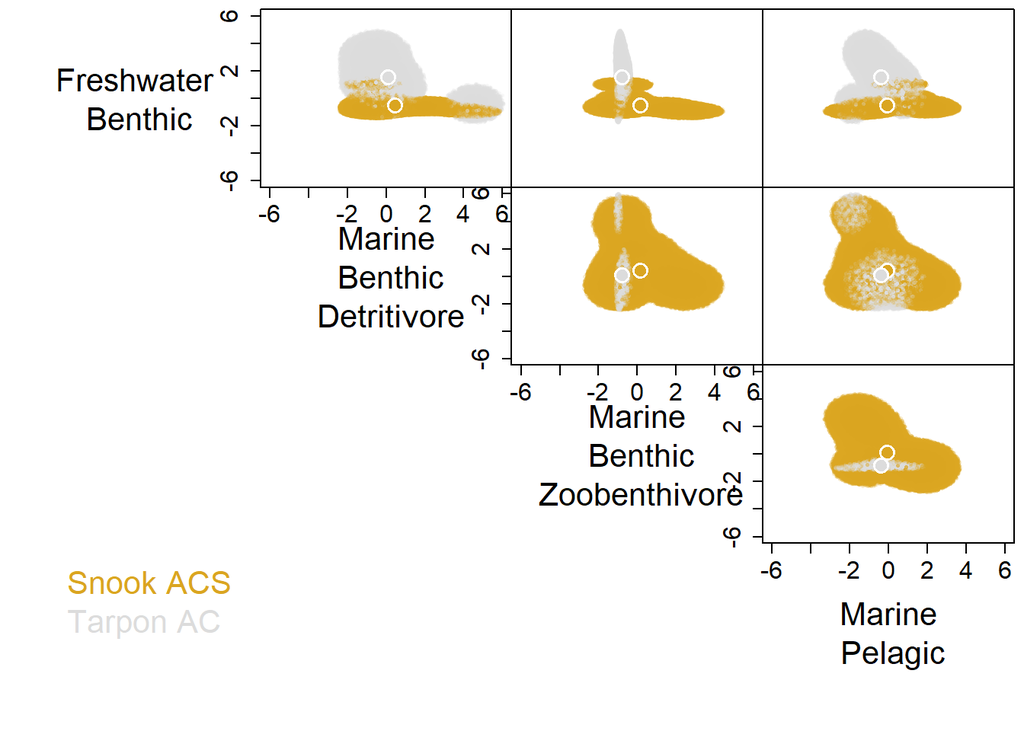

```r
# Alligator
hvAC= hypervolume_join(acSNhv, acTRhv)

plot(hvAC, pairplot = T, colors=c('goldenrod','gainsboro'),
     names= c("Freshwater\n Benthic",
              "Marine\n Benthic\n Detritivore",
              "Marine\n Benthic\n Zoobenthivore",
              "Marine\n Pelagic",
              "Trophic\n Position"),
     show.3d=FALSE,plot.3d.axes.id=NULL,
     show.axes=TRUE, show.frame=TRUE,
     show.random=T, show.density=TRUE,show.data=F,
     show.legend=T, limits=c(-6,6),
     show.contour=F, contour.lwd= 2,
     contour.type='alphahull',
     contour.alphahull.alpha=0.25,
     contour.ball.radius.factor=1,
     contour.kde.level=0.01,
     contour.raster.resolution=100,
     show.centroid=TRUE, cex.centroid=2,
     point.alpha.min=0.2, point.dark.factor=0.5,
     cex.random=0.5,cex.data=1,cex.axis=1.5,cex.names=2,cex.legend=2,
     num.points.max.data = 100000, num.points.max.random = 200000, reshuffle=TRUE,
     plot.function.additional=NULL,
     verbose=FALSE
)
```

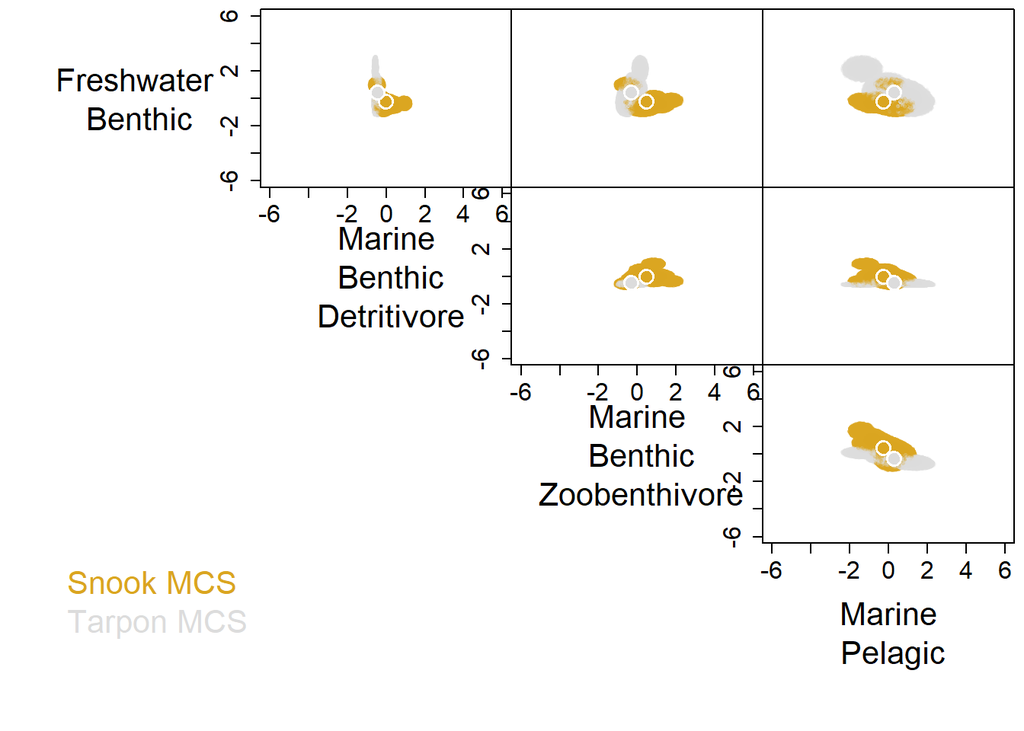

```r
# McCormick
hvMC= hypervolume_join(mcSNhv, mcTRhv)

plot(hvMC, pairplot = T, colors=c('goldenrod','gainsboro'),
     names= c("Freshwater\n Benthic",
              "Marine\n Benthic\n Detritivore",
              "Marine\n Benthic\n Zoobenthivore",
              "Marine\n Pelagic",
              "Trophic\n Position"),
     show.3d=FALSE,plot.3d.axes.id=NULL,
     show.axes=TRUE, show.frame=TRUE,
     show.random=T, show.density=TRUE,show.data=F,
     show.legend=T, limits=c(-6,6),
     show.contour=F, contour.lwd= 2,
     contour.type='alphahull',
     contour.alphahull.alpha=0.25,
     contour.ball.radius.factor=1,
     contour.kde.level=0.01,
     contour.raster.resolution=100,
     show.centroid=TRUE, cex.centroid=2,
     point.alpha.min=0.2, point.dark.factor=0.5,
     cex.random=0.5,cex.data=1,cex.axis=1.5,cex.names=2,cex.legend=2,
     num.points.max.data = 100000, num.points.max.random = 200000, reshuffle=TRUE,
     plot.function.additional=NULL,
     verbose=FALSE
)
```

Plots can be saved by adding image function (e.g. ,`tiff()`,`png()`, `jpeg()`) followed by the `plot()` and then finally `dev.off()`

```r
tiff("figs/MCSHV_sp.tiff", width = 9, height = 9, units = 'in',
     res = 600, compression = 'lzw')

plot(hvMC, pairplot = T, colors=c('goldenrod','gainsboro'),
     names= c("Freshwater\n Benthic",
              "Marine\n Benthic\n Detritivore",
              "Marine\n Benthic\n Zoobenthivore",
              "Marine\n Pelagic",
              "Trophic\n Position"),
     show.3d=FALSE,plot.3d.axes.id=NULL,
     show.axes=TRUE, show.frame=TRUE,
     show.random=T, show.density=TRUE,show.data=F,
     show.legend=T, limits=c(-6,6),
     show.contour=F, contour.lwd= 2,
     contour.type='alphahull',
     contour.alphahull.alpha=0.25,
     contour.ball.radius.factor=1,
     contour.kde.level=0.01,
     contour.raster.resolution=100,
     show.centroid=TRUE, cex.centroid=2,
     point.alpha.min=0.2, point.dark.factor=0.5,
     cex.random=0.5,cex.data=1,cex.axis=1.5,cex.names=2,cex.legend=2,
     num.points.max.data = 100000, num.points.max.random = 200000, reshuffle=TRUE,
     plot.function.additional=NULL,
     verbose=FALSE
)
dev.off()
```

### Calulating niche size

The function `hypervolume::get_volume()` can be used to calculate the niche size (volume)

```r
# Snook in ACS
get_volume(acSNhv)
```

```
## Snook ACS
##  115.0099
```

```r
# Snook in MCS
get_volume(mcSNhv)
```

```
## Snook MCS
##  4.855536
```

```r
# Tarpon in ACS
get_volume(acTRhv)
```

```
## Tarpon AC
##  24.60743
```

```r
# Tarpon in MCS
get_volume(mcTRhv)
```

```
## Tarpon MCS
##   1.706777
```

#### Bootstrapping niche size

`get_volume()` only generates a single volume, but estimating the confidence interval can be done with bootstrapping with the custom function `HVboot()`.

`data =` dataframe or tibble of z-scored values to make hvs

`n =` number of bootstrapped hvs to make

`frac =` fraction of data points to use to make bootstrapped hvs. Also be input as a whole number for how many data points to use in resampling of bootstraps

`vol = NULL` Default is NULL, but if `vol =` output `get_volume()` the volume and 95% interval will be printed

Returns vector of bootstrapped hvss a custom function that bootstraps the data to create a confidence interval for the estimate of niche size.

```r
HVboot = function(data, n, frac, vol = NULL){
  require(tidyverse)
  df = tibble(Volume = rep(NA, len = num))
  num = ceiling(frac*nrow(data))
  if(frac>1){
    num = frac
  }
  for (i in 1:n){
    rand = sample_n(data, num, replace = TRUE)
    require(hypervolume)
    randh = hypervolume_gaussian(rand,
                                 samples.per.point = 5000,
                                 kde.bandwidth = estimate_bandwidth(rand),
                                 sd.count = 3,
                                 quantile.requested = 0.95,
                                 quantile.requested.type = "probability",
                                 chunk.size = 1000,
                                 verbose = F)
    df$Volume[i] = as.numeric(get_volume(randh))
    if (i/num == .1){
      cat('10% done\n')
    } else if (i/num == 0.25){
      cat('25% done\n')
    }else if (i/num == 0.50){
      cat('50% done\n')
    }else if (i/num == 0.75){
      cat('75% done\n')
    }else if (i/num == 0.9){
      cat('90% done\n')
    }
  }
  if (is.null(vol) == F){
    cat('Volume (95% CI) = ', vol, ' (',
        quantile(df$Volume, 0.025, na.rm = T), '-',
        quantile(df$Volume, 0.975, na.rm = T), ')\n')
  }
  return(df)
}
```

Run for each species in each system

```r
# Snook in ACS
acSNhvCI = HVboot(acSN, 100, 0.75, vol = 115.0)
acSNhvCI$Species = 'Snook'
acSNhvCI$System = 'ACS'

# Snook in MCS
mcSNhvCI = HVboot(mcSN, 100, 0.75, vol = 4.9)
mcSNhvCI$Species = 'Snook'
mcSNhvCI$System = 'MCS'

# Tarpon in ACS
acTRhvCI = HVboot(acTR, 100, 0.75, vol = 24.6)
acTRhvCI$Species = 'Tarpon'
acTRhvCI$System = 'ACS'

# Tarpon in MCS
mcTRhvCI = HVboot(mcTR, 100, 0.75, vol = 1.7)
mcTRhvCI$Species = 'Tarpon'
mcTRhvCI$System = 'MCS'

# bind all together
hvCI = bind_rows(acSNhvCI, mcSNhvCI, acTRhvCI, mcTRhvCI)

hvCI
```

```
## # A tibble: 400 x 3
##    Volume Species System
##     <dbl> <chr>   <chr>
##  1  137.  Snook   ACS
##  2  113.  Snook   ACS
##  3  138.  Snook   ACS
##  4  101.  Snook   ACS
##  5   88.6 Snook   ACS
##  6  211.  Snook   ACS
##  7  139.  Snook   ACS
##  8   60.0 Snook   ACS
##  9  164.  Snook   ACS
## 10  141.  Snook   ACS
## # ... with 390 more rows
```

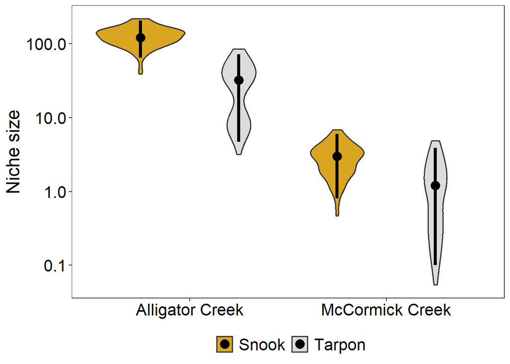

### Calculate overlap

Overlap is a measure of the similarity between two hypervolumes. It takes into account both the position and the size of the hypervolumes. So to have high overlap, the hypervolumes need to be both similar in size and located in the same *n*-dimensional space.

To calculate overlap, hypevolumes need to be joined with `hypervolume::hypervolume_set()`. To calculate the metrics `hypervolume::hypervolume_overlap_statistics()`. This function calculates 4 metrics that are related to the overlap of the two hypervolumes

*jaccard*: Jaccard similarity (volume of intersection of 1 and 2 divided by volume of union of 1 and 2)

*sorensen*: Sorensen similarity (twice the volume of intersection of 1 and 2 divided by volume of 1 plus volume of 2)

*fraq_uniq_1*: Unique fraction of hypervolume 1 (volume of unique component of 1 divided by volume of 1))

*fraq_uniq_2*: Unique fraction of hypervolume 2 (volume of unique component of 2 divided by volume of 2))

```r
# alligator overlap
AC = hypervolume_set(acSNhv, acTRhv,  check.memory = F, verbose = F)
```

```
##
## Building tree...
## done.
## Ball query...
##
## done.
##
## Building tree...
## done.
## Ball query...
##
## done.
```

```r
hypervolume_overlap_statistics(AC)
```

```
##       jaccard      sorensen frac_unique_1 frac_unique_2
##    0.05976708    0.11279286    0.93153703    0.68001870
```

```r
# mccormick overlap
MC = hypervolume_set(mcSNhv, mcTRhv, check.memory = F, verbose = F)
```

```
##
## Building tree...
## done.
## Ball query...
##
## done.
##
## Building tree...
## done.
## Ball query...
##
## done.
```

```r
hypervolume_overlap_statistics(MC)
```

```
##       jaccard      sorensen frac_unique_1 frac_unique_2
##    0.06711846    0.12579382    0.91499410    0.75817037
```

#### Bootstrapping overlap metrics

Similar to niche size, in order to calculate a confidence interval, overlap needs to be bootstrapped. `bootOverlap()` is a custom function that bootstrap overlap metrics between 2 hypervolumes.

`data1 =` tibble or dataframe of z-scored data for hv 1

`data2 =` tibble or dataframe of z-scored data for hv 2

`n =` number of iterations to run for bootstrapping

`frac =` fraction of data points to use to make bootstrapped hvs. Can also be input as a whole number for how many data points to use in resampling of bootstraps

returns dataframe with sorensen overlap and amount unique of each hv

```r
bootOverlap = function(data1,data2,n,frac){
  require(tidyverse)
  df = tibble(sorensen = rep(NA, n), unique1 = NA, unique2 = NA)
  n1 = ceiling(frac*nrow(data1))
  if(frac>1){
    n1 = frac
  }
  n2 = ceiling(frac*nrow(data2))
  if(frac>1){
    n2 = frac
  }
  for (i in 1:num){
    rand1 = sample_n(data1, n1, replace = T)
    rand2 = sample_n(data2, n2, replace = T)
    require(hypervolume)
    randh1 = hypervolume_gaussian(rand1,
                                  samples.per.point = 5000,
                                  kde.bandwidth = estimate_bandwidth(rand1),
                                  sd.count = 3,
                                  quantile.requested = 0.95,
                                  quantile.requested.type = "probability",
                                  chunk.size = 1000,
                                  verbose = F)
    randh2 = hypervolume_gaussian(rand2,
                                  samples.per.point = 5000,
                                  kde.bandwidth = estimate_bandwidth(rand2),
                                  sd.count = 3,
                                  quantile.requested = 0.95,
                                  quantile.requested.type = "probability",
                                  chunk.size = 1000,
                                  verbose = F)
    set = hypervolume_set(randh1,randh2,check.memory = F, verbose = F)
    df$sorensen[i] = hypervolume_overlap_statistics(set)[2]
    df$unique1[i] = hypervolume_overlap_statistics(set)[3]
    df$unique2[i] = hypervolume_overlap_statistics(set)[4]

    if (i/num == .1){
      cat('10% done\n')
    } else if (i/num == 0.25){
      cat('25% done\n')
    }else if (i/num == 0.50){
      cat('50% done\n')
    }else if (i/num == 0.75){
      cat('75% done\n')
    }else if (i/num == 0.9){
      cat('90% done\n')
    }

  }
  return(df)
}
```

Calculate bootstrap overlap metrics

```r
#Alligator
ovAC = bootOverlap(acSN, acTR, 100, 0.75)
ovAC$comp = 'Species'
ovAC$type = 'ACS'

#McCormick
ovMC = bootOverlap(mcSN, mcTR, 100, 0.75)
ovMC$comp = 'Species'
ovMC$type = 'MCS'

# bind data together
OV = bind_rows(ovAC, ovMC)
OV
```

```
## # A tibble: 200 x 5
##    sorensen unique1 unique2 comp    type
##       <dbl>   <dbl>   <dbl> <chr>   <chr>
##  1   0.0660   0.965   0.454 Species ACS
##  2   0.0956   0.942   0.734 Species ACS
##  3   0.0157   0.991   0.931 Species ACS
##  4   0.0730   0.947   0.883 Species ACS
##  5   0.141    0.905   0.731 Species ACS
##  6   0.0537   0.971   0.559 Species ACS
##  7   0.0943   0.944   0.703 Species ACS
##  8   0.0893   0.947   0.701 Species ACS
##  9   0.151    0.904   0.648 Species ACS
## 10   0.0554   0.971   0.373 Species ACS
## # ... with 190 more rows
```

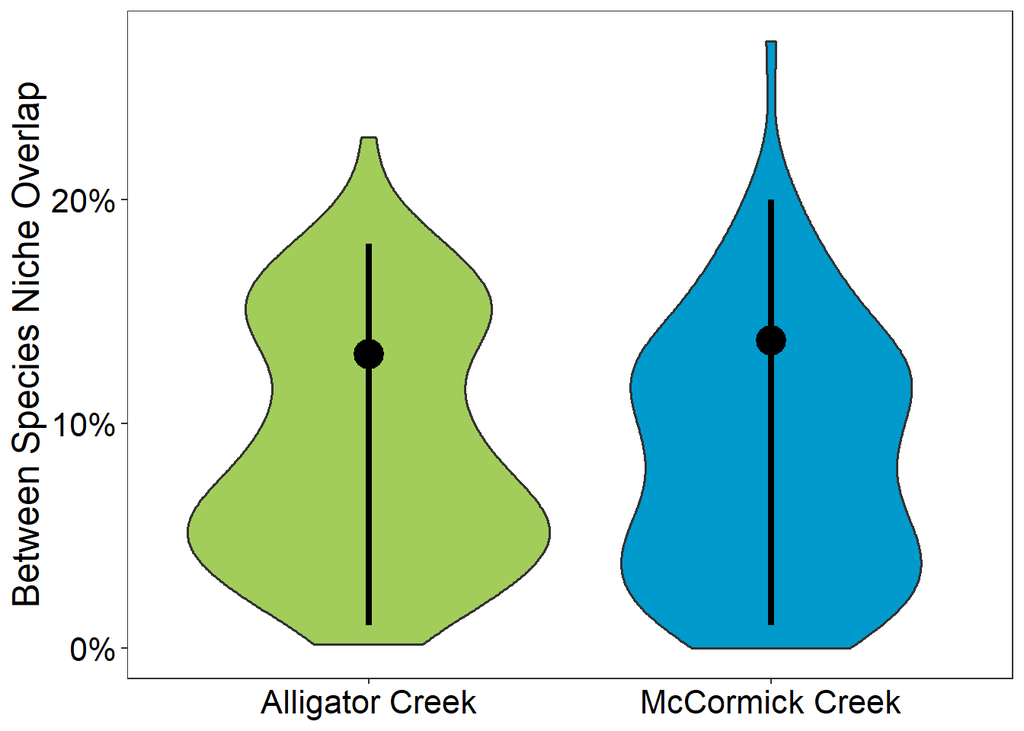

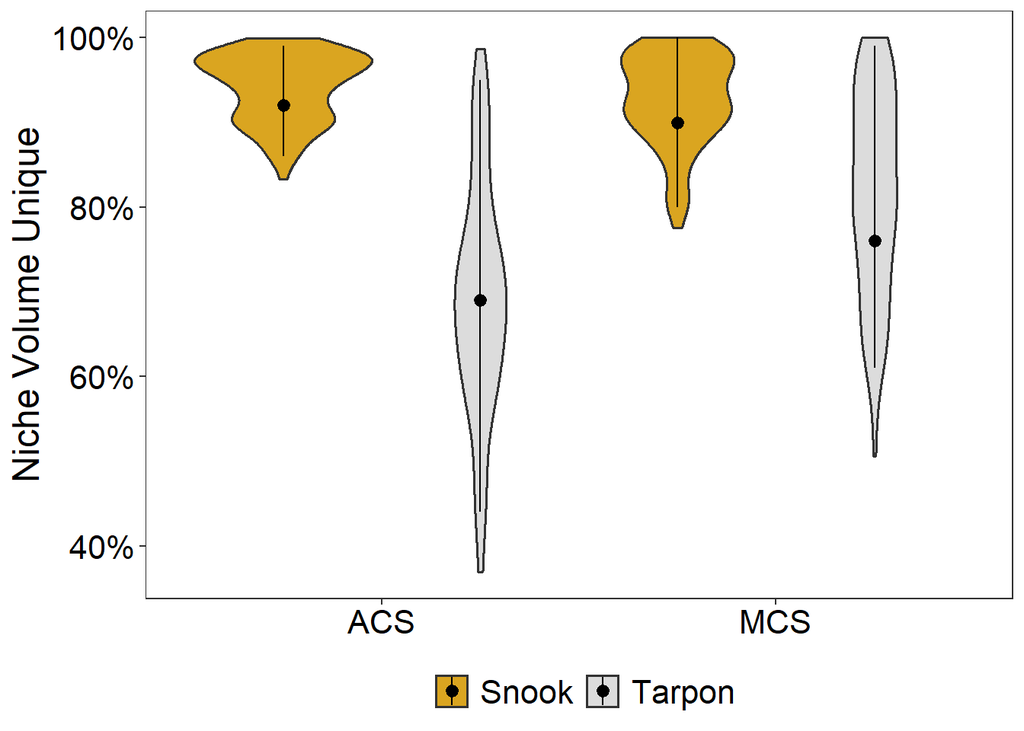